[GitHub](https://github.com/Janssena/DeepCompartmentModels.jl)[](https://github.com/Janssena/DeepCompartmentModels.jl/blob/main/tutorials/11-occasions.qmd)

# Tutorial 11: Inter-Occasion Variability and Occasions

*Modelling repeated treatment periods and understanding the solve return structure*

## Introduction

In many clinical studies, patients are observed over multiple **occasions** — separated periods of treatment and wash-out. Common examples:

- **Crossover designs:** Period A (drug) → wash-out → Period B (drug at new dose)
- **TDM visits:** Repeated outpatient visits, each treated independently
- **Multi-cycle chemotherapy:** Cycle 1 → rest → Cycle 2 → rest → …

Between occasions the drug washes out completely, so the ODE must **restart from a fresh initial condition** at each occasion start rather than continuing from the previous state. DeepCompartmentModels.jl handles this via the `occasions` keyword on `Individual`.

This tutorial focuses on the **data structure and solving behaviour**, not model training. Key concepts:

1. What `occasions` means structurally
2. How to construct individuals with multiple occasions
3. How `solve` returns a **vector of solutions** (one per occasion)
4. How to work with that vector for visualisation and analysis

## Setup

```julia
using DeepCompartmentModels   # also re-exports Lux, Optimisers, OrdinaryDiffEq, ...
using Random
using CairoMakie
```

## 1 — An individual without occasions (baseline)

First, observe the default behaviour without occasions. A single `solve` call returns one solution that spans the entire time horizon — the ODE state carries forward continuously, including any residual drug from previous doses.

```julia
# Two doses 96 hours apart — the ODE integrates continuously across the gap
A_single = Float32[
    0f0   100f0  200f0  0.5f0   # dose 1 at t=0
    96f0  100f0  200f0  0.5f0   # dose 2 at t=96h
]
cb_single = generate_dosing_callback(A_single, Float32)

t_obs = Float32.(vcat(1:2:24, 97:2:120))   # observations near each dose
y_obs = zeros(Float32, length(t_obs))

indv_no_occ = Individual(1, Float32[70f0], t_obs, y_obs, cb_single, Float32)

println("Individual type: $(nameof(typeof(indv_no_occ)))")
println("occasions field: $(indv_no_occ.occasions)")   # Nothing

# Solve with known PK parameters [CL, Vd]
z = Float32[3.0, 20.0]
model_1c = DCM(one_comp!, Lux.Chain(Normalize([70f0]), Lux.Dense(1, 2, Lux.softplus)))

sol_single = solve(model_1c, indv_no_occ, z)
typeof(sol_single)
```

[output not shown]

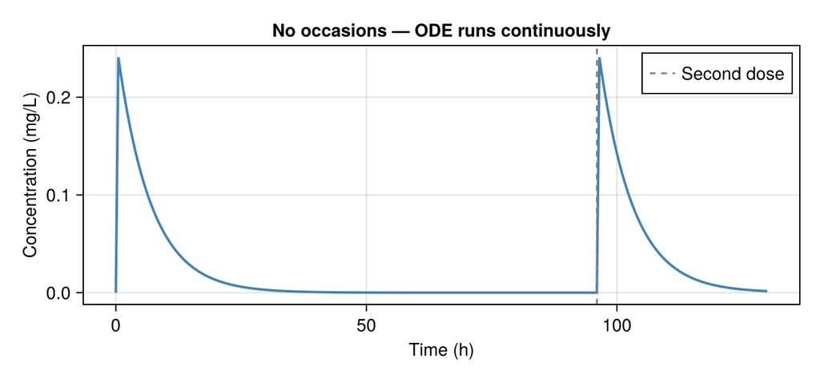

```julia
println("Solution type without occasions: $(nameof(typeof(sol_single)))")
t_sol = Float32.(0:0.5:130)
conc_single = solve(model_1c.problem, indv_no_occ, z; saveat=t_sol) |>
    sol -> Array(sol)[1, :] ./ z[2]   # concentration = amount / Vd

fig = Figure(size=(650, 300))
ax  = Axis(fig[1,1], xlabel="Time (h)", ylabel="Concentration (mg/L)",
           title="No occasions — ODE runs continuously")
lines!(ax, t_sol, conc_single; color=:steelblue, linewidth=2)
vlines!(ax, [96f0]; color=:gray, linestyle=:dash, label="Second dose")
axislegend(ax)
fig
```

Notice how the second dose adds on top of any residual concentration from the first period — the ODE state is *not* reset.

## 2 — Adding occasions

The `occasions` keyword takes a `Vector{Pair{T,T}}` — each pair defines the `(start, end)` time of one occasion. The ODE is restarted with `u0 = 0` (or the individual's `u0` field) at the beginning of each occasion.

```julia
# Two treatment periods with full washout between them
# Period 1: 0 → 72 h  |  wash-out  |  Period 2: 168 → 240 h
occasions = [0f0 => 72f0, 168f0 => 240f0]

# Each period has its own dose at the start
A_occ = Float32[
    0f0    100f0  200f0  0.5f0   # Period 1 dose at t=0
    168f0  100f0  200f0  0.5f0   # Period 2 dose at t=168h
]
cb_occ = generate_dosing_callback(A_occ, Float32)

# Observations within each period
t_p1 = Float32.(1:4:72)   # period 1
t_p2 = Float32.(169:4:240)  # period 2
t_occ_obs = vcat(t_p1, t_p2)
y_occ_obs = zeros(Float32, length(t_occ_obs))

indv_occ = Individual(2, Float32[70f0], t_occ_obs, y_occ_obs, cb_occ, Float32;
    occasions = occasions)

println("Individual type: $(nameof(typeof(indv_occ)))")
println("Number of occasions: $(length(indv_occ.occasions))")
println("Period 1: $(indv_occ.occasions[1])")
println("Period 2: $(indv_occ.occasions[2])")
```

```
Individual type: BasicIndividual
Number of occasions: 2
Period 1: 0.0f0 => 72.0f0
Period 2: 168.0f0 => 240.0f0
```

## 3 — `solve` returns a Vector of solutions

This is the key structural difference. When `occasions` is set, `solve` returns `Vector{ODESolution}` — one element per occasion — rather than a single solution.

```julia
sols = solve(model_1c, indv_occ, z)

println("Return type: $(typeof(sols))")
println("Number of solutions: $(length(sols))")
println("Solution 1 type: $(nameof(typeof(sols[1])))")
println("Solution 2 type: $(nameof(typeof(sols[2])))")
```

[output not shown]

```julia
# Each solution spans only its own occasion time window
println("\nSolution 1 time span: $(sols[1].t[[1,end]])")
println("Solution 2 time span: $(sols[2].t[[1,end]])")
```

```
Solution 1 time span: Float32[1.0, 69.0]
Solution 2 time span: Float32[169.0, 237.0]
```

Each solution starts the ODE fresh from `u0` — there is no accumulation across the wash-out period.

## 4 — Extracting predictions from each occasion

Work with the vector of solutions by indexing or iterating.

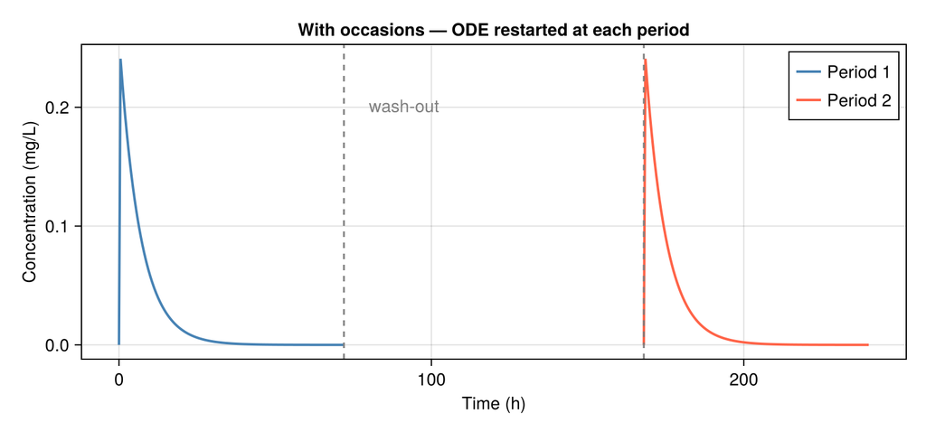

```julia
t_dense_p1 = Float32.(0:0.5:72)
t_dense_p2 = Float32.(168:0.5:240)

# Re-solve at a dense grid. `saveat` covers both periods; each occasion only saves
# the times that fall inside its own window.
sols_dense = solve(model_1c.problem, indv_occ, z; saveat = vcat(t_dense_p1, t_dense_p2))

conc_p1 = Array(sols_dense[1])[1, :] ./ z[2]   # amount → concentration
conc_p2 = Array(sols_dense[2])[1, :] ./ z[2]

fig = Figure(size=(750, 350))
ax  = Axis(fig[1,1], xlabel="Time (h)", ylabel="Concentration (mg/L)",
           title="With occasions — ODE restarted at each period")

lines!(ax, t_dense_p1, conc_p1; color=:steelblue, linewidth=2, label="Period 1")
lines!(ax, t_dense_p2, conc_p2; color=:tomato,    linewidth=2, label="Period 2")
vlines!(ax, [72f0, 168f0]; color=:gray, linestyle=:dash)
text!(ax, 80f0, maximum(conc_p1)*0.8; text="wash-out", color=:gray)
axislegend(ax; position=:rt)
fig
```

Compare: when occasions are used, Period 2 starts from zero — the wash-out is respected. Without occasions, the second dose would add on top of residual drug.

## 5 — `predict` and the occasions return structure

`predict` (and `solve_for_target`) also return a vector when called on an individual with occasions. The result is `Vector{Vector{T}}` — one concentration vector per occasion.

```julia
# predict returns a vector of vectors when occasions are set
# (because solve_for_target maps _take_target over each ODESolution)
ps, st = setup(SSE(), Random.Xoshiro(1), model_1c)
ŷ_occasions = predict(model_1c, indv_occ, ps, st)
println("Number of occasions: $(length(ŷ_occasions))")
println("Predictions per occasion: $(length.(ŷ_occasions))")
```

```
Number of occasions: 2
Predictions per occasion: [18, 18]
```

Note

In practice, you call `predict` after training a model with `setup` and `fit`. The code above is illustrative; see Tutorial 8 for a complete training workflow. The important point is that `predict` mirrors the `solve` structure: it returns `Vector{Vector{T}}` when occasions are present.

```julia
# More practical: solve directly with known z
function predict_occasions(model, indv, z; t_per_occ)
    results = []
    for (occ, t_occ) in zip(indv.occasions, t_per_occ)
        _prob = remake(model.problem;
            tspan = (occ.first - 0.1f0, occ.second),
            u0    = zeros(Float32, length(model.problem.u0)),
            p     = vcat(z, 0f0),
        )
        sol = solve(_prob, Tsit5();
            callback = indv.callback,
            saveat   = t_occ,
            tstops   = indv.callback.condition.times,
        )
        push!(results, sol)
    end
    return results
end

sols_per_occ = predict_occasions(
    model_1c, indv_occ, z;
    t_per_occ = [t_dense_p1, t_dense_p2],
)

println("Returned $(length(sols_per_occ)) solutions, one per occasion")
```

```
Returned 2 solutions, one per occasion
```

## 6 — Varying parameters across occasions (IOV)

**Inter-occasion variability (IOV)** means PK parameters differ between periods for the same patient — e.g. due to food effects, enzyme induction, or physiological changes. A simple way to demonstrate this is to use different `z` values per occasion when solving manually.

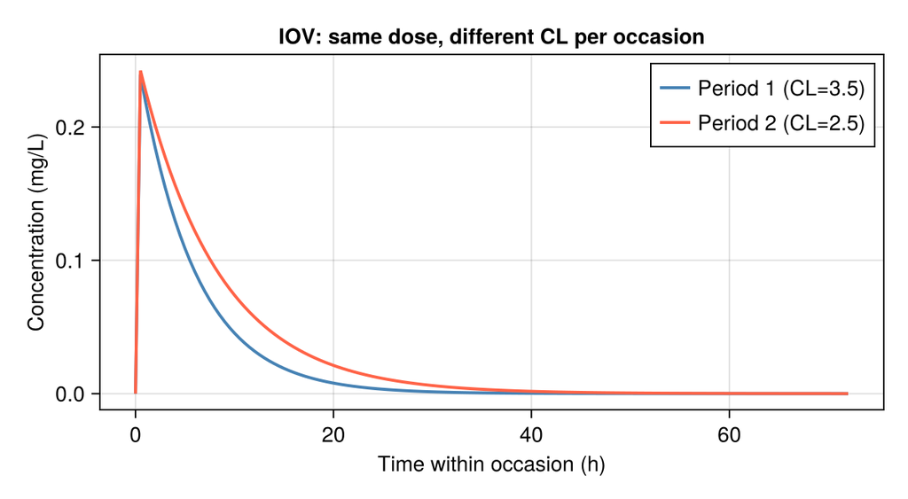

```julia
# Simulate: Period 1 has higher CL (e.g. fed state induces metabolism)
z_p1 = Float32[3.5, 20.0]   # CL=3.5 in period 1
z_p2 = Float32[2.5, 20.0]   # CL=2.5 in period 2 (fasted, lower clearance)

function solve_at_density(problem, z, t_dense, cb)
    prob = remake(problem; u0=zeros(Float32, 1), p=vcat(z, 0f0),
                  tspan=(-0.1f0, maximum(t_dense)))
    sol = solve(prob, Tsit5(); callback=cb, saveat=t_dense,
                tstops=cb.condition.times)
    return Array(sol)[1, :] ./ z[2]
end

cb_p1 = generate_dosing_callback(Float32[0f0  100f0  200f0  0.5f0], Float32)
cb_p2 = generate_dosing_callback(Float32[0f0  100f0  200f0  0.5f0], Float32)

conc_iov_p1 = solve_at_density(model_1c.problem, z_p1, Float32.(0:0.5:72),  cb_p1)
conc_iov_p2 = solve_at_density(model_1c.problem, z_p2, Float32.(0:0.5:72),  cb_p2)

fig = Figure(size=(600, 330))
ax  = Axis(fig[1,1], xlabel="Time within occasion (h)", ylabel="Concentration (mg/L)",
           title="IOV: same dose, different CL per occasion")
lines!(ax, Float32.(0:0.5:72), conc_iov_p1; color=:steelblue, linewidth=2, label="Period 1 (CL=3.5)")
lines!(ax, Float32.(0:0.5:72), conc_iov_p2; color=:tomato,    linewidth=2, label="Period 2 (CL=2.5)")
axislegend(ax)
fig
```

## 7 — Building a crossover population

A realistic crossover dataset has each subject completing two treatment periods. Here is the full construction pattern:

```julia
function make_crossover_individual(id, weight, dose_p1, dose_p2, t_p1, t_p2, y_p1, y_p2,
                                    ::Type{T}=Float32) where T
    # Both doses described in a single callback
    A = T[0f0    dose_p1  dose_p1/(T(0.5))  T(0.5)
          168f0  dose_p2  dose_p2/(T(0.5))  T(0.5)]
    cb = generate_dosing_callback(A, T)

    # Observation times and data from both periods
    t_all = vcat(T.(t_p1), T.(t_p2))
    y_all = vcat(T.(y_p1), T.(y_p2))

    occasions = [T(0) => T(72), T(168) => T(240)]

    return Individual(id, T[weight], t_all, y_all, cb, T; occasions=occasions)
end

# Simulate some crossover subjects
rng = Random.Xoshiro(1)
function sim_crossover(id, weight)
    CL  = Float32(2.5 * (weight/70)^0.75)
    Vd  = Float32(20.0 * (weight/70))
    k   = CL / Vd

    t_obs = Float32.(1:6:72)

    # Period 1: 100 mg
    conc_p1 = (100f0/Vd) .* exp.(-k .* t_obs) .+ 0.1f0 .* randn(rng, Float32, length(t_obs))

    # Period 2: 150 mg
    conc_p2 = (150f0/Vd) .* exp.(-k .* t_obs) .+ 0.1f0 .* randn(rng, Float32, length(t_obs))

    t_p2 = t_obs .+ 168f0   # shifted to Period 2 clock time

    return make_crossover_individual(id, Float32(weight),
        100f0, 150f0,
        t_obs, t_p2,
        max.(conc_p1, 0f0), max.(conc_p2, 0f0))
end

crossover_pop = Population([sim_crossover(i, 55 + 5*i) for i in 1:8])
println("Crossover population: $(length(crossover_pop)) subjects")
println("Subjects with occasions: $(sum(!isnothing(indv.occasions) for indv in crossover_pop))")
println("Periods per subject: $(length(crossover_pop[1].occasions))")
```

```
Crossover population: 8 subjects
Subjects with occasions: 8
Periods per subject: 2
```

## Summary

| Concept | Code |
| --- | --- |
| Add occasions | `Individual(id, x, t, y, cb, T; occasions=[t1=>t2, t3=>t4])` |
| No occasions | `solve` returns `ODESolution` |
| With occasions | `solve` returns `Vector{ODESolution}`, one per period |
| `predict` return | `Vector{T}` (no occasions) or `Vector{Vector{T}}` (with occasions) |
| ODE restart | Fresh `u0` at each occasion start — no accumulation across wash-out |
| IOV | Apply different `z` per occasion when calling `solve` directly |